# Object-oriented scientific programming with C++

Matthias Möller, Jonas Thies, Cálin Georgescu, Jingya Li (Numerical Analysis, DIAM)

Lecture 5

## Goal of this lecture

Enumerators

Type aliases

Variadic template parameters

C++ standard container classes and algorithms

Iterators

Range-based and for-each for loops

## Enumerators

Enumerators make it possible to collect named values `enum Color { red, green, blue };`

Named values are mapped to, e.g., `red=0, green=1, blue=2`

Usage

```
Color col = Color::red; switch col {
      case Color::red:   // do something
          break;
      case Color::green: // do something else
          break;
}
```

## Enumerators

Enumerators can be initialised explicitly

```
enum Color { red=2, green=4, blue=8 };
```

Enumerators can be derived from a particular integral type

```
enum Color : int { red=2, green=4, blue=8 };
```

Enumerators can make use of arithmetic operations

```
enum Color { red=2, green=4, blue=8,
               cyan = red + green   };
```

However, an enumerator must not occur more than once

`enum TrafficLight {`red`, yellow,`green`};`

## Scoped Enumerators

C++11 introduces **scoped enumerators** which can occur more than once (since they have different scopes!)

```
enum class Color { red, green, blue };
enum class TrafficLight { red, yellow, green };
```

For the rest, scoped enumerators can be used exactly in the same way as non-scoped enumerators

```
enum class Color { red=2, green=4, blue=8 };
enum class Color : int { red=2, green=4, blue=8 };
enum class Color { red=2, green=4, blue=8,
                   cyan = red + green   };
```

## Type aliases

*Implementation I*: type aliases via typedef

```
template<typename T, T v>
struct trait {
      typedef T type;           // type is a type
      static const T value = v; // value is a variable
  };
```

*Implementation II (since C++11)*: type aliases via using

```
template<typename T, T v>
struct trait {
      using type = T;           // type is a type
      static const T value = v; // value is a variable
  };
```

## Type aliases

https://www.online-ide.com/RLlfvTsGpK

```
#include <iostream>
#include <typeinfo>


template<typename T, T v>
struct trait {
    typedef T type;           // type is a type
    static const T value = v; // value is a variable
};

int main() {
    typedef trait<int, 10> mytrait; // before C++11
    // using mytrait = trait<int, 10>; // since C++11

    std::cout << mytrait::value << " "
              << typeid(mytrait::type).name()
              << std::endl;

    return 0;
}
```

## Intermezzo: `using` vs. `typedef`

Remember the function pointers from session 3

```
#include <iostream>
double myfunc0(double x) { return x; }

using funcPtr = double(*) (double);
funcPtr f = myfunc0;
std::cout << f(2.3) << std::endl;
```

```
2.3
```

## Intermezzo: `using` vs. `typedef`

This becomes much less intuitive with typedef

```
#include <iostream>

double myfunc1(double x) {
    return x;
}

typedef double (funcPtr)(double); // Function pointer type
funcPtr* f = myfunc1;               // Assign myfunc1 to pointer f
std::cout << f(2.3) << std::endl;  // Use the function pointer to call myfunc1
```

```
2.3
```

```
@0x7f2a8206dde0
```

## Variadic templates

**Task:** implement a function that takes an **arbitrary number** of possibly **different variables** and computes their sum

```
cout << sum(1.0)                                  << endl;
cout << sum(1.0, 1.0)                             << endl;
cout << sum(1.0, (int)1)                          << endl;
cout << sum(1.0, (int)1, (float)1.3, (double)1.3) << endl;
```

## Variadic templates

None of the template meta programming techniques we know so far will solve this problem with satisfaction

New concept in C++11: **variadic template parameters**

**Idea:** reformulate the problem as “one + rest”:

`sum(x1,x2,x3,...,xn) = x1 + sum(x2,x3,...,xn)`

That is, we combine recursion and function overloading with the ability to accept an arbitrary parameter list

## Variadic templates

Function overload for **one argument**

```
template<typename T>
double sum(T arg) { return arg; }
```

Function overload for **more than one argument**

```
template<typename T, typename ... Ts>
double sum(T arg, Ts ... args)
{ return arg + sum(args...); }
```

The **template parameter pack**

```
template<typename ... Ts>
```

accepts zero or more template arguments but there can only be one template parameter pack per function.

## Variadic templates

The number of arguments in the parameter pack can be detected using the `sizeof...()` function

```
template<typename ... Ts>
  int length(Ts ... args)
  {
      return sizeof...(args);
  }
```

**Task:** Write a type trait that determines the number of arguments passed to a function as parameter pack. In other words, implement the `sizeof...()` function yourself.

## Automatic return type deduction

**Task:** Implement the sum function for an arbitrary number of parameters using automatic return type deduction

Function overload for **one argument** (with C++11)

```
template<typename T>
auto sum(T arg) -> decltype(arg)
{ return arg; }
```

Function overload for **one argument** (with C++14)

```
template<typename T>
auto sum(T arg)
{ return arg; }
```

## Automatic return type deduction

Function overload for **more than one argument** (C++11)

```
template<typename T, typename ... Ts>
auto sum(T arg, Ts ... args)
-> typename std::common_type<T, Ts...>::type
  { return arg + sum(args...); }
```

Function overload for **more than one argument** (C++14)

```
template<typename T, typename ... Ts>
  auto sum(T arg, Ts ... args)
  { return arg + sum(args...); }
```

## C++ standard containers

**Aim:** provide a set of universal container classes that

- can **store arbitrary types** (in general, only objects of the same type (in each container; `std::tuple` for multi-type containers)
- provide a **uniform interface** to insert, delete, access, and manipulate, items and iterate over the items stored
- provide optimal implementations of **standard data structures**, e.g., double-linked lists, balanced trees (red-black tree)

## C++ standard containers

• `std::array`:array with compile-time size (non-resizable)

• `std::vector`:array with run-time size (resizable)

• `std::list`:double-linked list

• `std::forward_list`:single-linked list

• `std::stack`:Last-In-First-Out stack

• `std::queue`:First-In-First-Out queue

• `std::set/std::multiset`:Set of unique elements

• `std::map/std::multimap`:Set of (key,value) elements

## C++ standard containers

Container classes support the following base functionality

- `size()`: returns the size of the container
- `empty()`: returns true of the container is empty
- `swap(container& other)`: swaps contents of containers Many container classes provide so-called **iterators**
- `begin()`, `end()`: editable iterator
- `cbegin()`, `cend()`: constant, i.e., non-editable iterator

## Simple array example

https://www.online-ide.com/VxJaDz7Avm

```
#include <array>
std::array<int, 5> a = {1, 2, 3, 4, 5};
std::cout << "empty: " << a.empty() << ”\n”;
std::cout << "size: " << (int) a.size() << ”\n”;
std::cout << "max_size:" << (int) a.max_size() << “\n”;
for (auto i = 0; i < a.size(); i++)
    std::cout << a[i] << “\n”;
```

## Simple array example

```
#include <iostream>
#include <array>


std::array<int, 5> a = {1, 2, 3, 4, 5};
std::array<int, 4> b = {6, 7, 8, 9};

//a.swap(b); //Uncomment this line to see what will happen

std::cout << "size: " << (int) a.size() << "\n";
std::cout << "size: " << (int) b.size() << "\n";
```

```
size: 5
size: 4
```

## Simple vector example

https://www.online-ide.com/OSemrgPAEK

```
#include <iostream>
#include <vector>

  std::vector<int> v;
  v.reserve(20);
  v.push_back(42);
  v.push_back(11);
  v.push_back(1);
// ... additional push_back operations if needed
  for (auto i = 0; i < v.size(); ++i)
      std::cout << v[i] << "\n";
```

## Iterators

Fixed size arrays

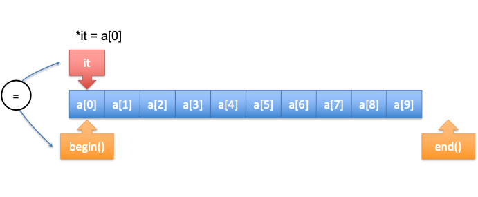

## Iterators

Fixed size arrays

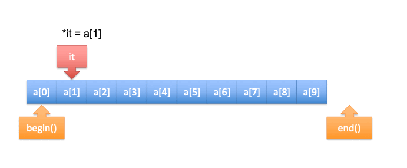

## Iterators

Fixed size arrays

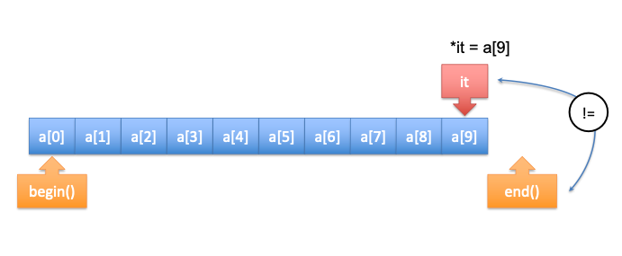

## Iterators

Fixed size arrays

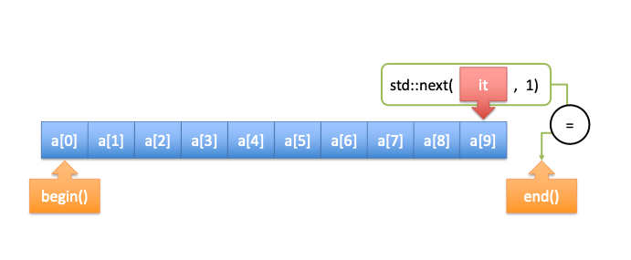

## Simple vector example

**Constant iterator** over all entries

```
for (auto it = a.cbegin(); it != a.cend(); ++it)
      std::cout << *it << “\n”;
```

**Non-constant iterator** over all entries

```
for (auto it = a.begin(); it != a.end(); ++it)
    *it++;
```

More elegant screen output using **ternary operator**

```
for (auto it = a.cbegin(); it != a.cend(); ++it)
      std::cout << *it
                << (std::next(it,1) != a.cend() ? "," : "\n");
```

## Simple vector example

The **ternary operator** `?:` implements an **inline if**

```
(condition ? true case : false case)
```

Usage:

```
– std::cout << (x>y ? x : y) << “\n”;
– (x>y ? x : y) = 1;
– auto myfunc(int x, double y) // in C++14 {
        return (x>y ? x : y);
    }
```

## Simple vector example

**Range-based for loop** (since C++11)

```
// access by constant reference (cannot modify i at all) for ( const auto& i : a )
      std::cout << i << “\n”;
  // access by value (modify the local copy)
  for ( auto i : a )
      std::cout << i++ << “\n”;
// access by reference (modify the original data) for ( auto&& i : a )
      std::cout << i++ << “\n”;
```

## Range-based for loops

Range-based for loops can be used with nearly all types

```
#include <iostream>
#include <array>
for ( int n : {0, 1, 2, 3, 4} )
      std::cout << n << " ";
for ( double h : {0.1, 0.05, 0.025, 0.0125} )
      //auto sol = solve_poisson(h); //Here you can iteratively call the function
```

```
0 1 2 3 4
```

Why **nearly**?

```
for ( auto c : {std::array<int,5>(); std::array<int,1>()})
    std::cout << c.size() << "\n";
```

```
auto array1 = std::array<int, 5>();
std::cout << typeid(array1).name() << "\n";
auto array2 = std::array<int, 1>();
std::cout << typeid(array2).name() << "\n";
```

```
St5arrayIiLm5EE
St5arrayIiLm1EE
```

## C++ standard algorithms

Header file `algorithm` provides many standard algorithms

– `for_each(begin, end, function)`

– `position = find(begin, end, x)`

– `position = find_if(begin, end, function)`

– `number = count(begin, end, x)`

– `number = count_if(begin, end, function)`

– `sort(begin, end)`

– `sort(begin, end, function)`

– `position = merge(begin1, end1, begin2, end2, out)`

## For-each loops

For-each loop iterates over all items and applies a user- defined unary function realized as lambda expression

https://www.online-ide.com/VrE05oFfZe

```
std::vector<int> v = {1, 2, 3, 4, 5};
std::for_each(v.begin(), v.end(),
              [](const int& n) { std::cout << " " << n; });
std::for_each(v.begin(), v.end(), [](int &n){ n++; });
```

## For-each loops

For-each loop iterates over all items and applies a user- defined unary function realized as function object

https://www.online-ide.com/PNHB7kuGvX

```
struct Sum {
    Sum() : sum(0) {}
    void operator()(int n) { sum += n; }
    int sum;
};

Sum s = std::for_each(v.begin(), v.end(), Sum());
std::cout << “sum: “ << s.sum << “\n”;
```

## Simple vector example

https://www.online-ide.com/fgqks71DQc

```
#include <vector>
#include <algorithm>
  std::vector<int> v;
  v.reserve(20);
  v.push_back(42);
  v.push_back(11);
  v.push_back(1);
  std::sort(v.begin(), v.end());
  for (const auto& i : v)
      std::cout << i << std::endl;
```

## Simple vector example

Provide standard library **compare function object**

```
#include <functional>
std::sort(v.begin(), v.end(), std::greater<int>() );
```

Provide user-defined **comparison as lambda expression**

```
std::sort(v.begin(), v.end(),
            [](int x, int y) { return y<x; } );
```

## Simple vector example

Provide user-defined **comparison as function object**

```
struct {
      bool operator()(int x, int y) { return y>x; }
      } customGreater;
std::sort(v.begin(), v.end(), customGreater );
```

## The power of iterators

C++ standard library functionality is largely based on iterators rather than absolute access via `operator[]`

For data structures like `std::list` the `operator[]` is not even defined since items can be inserted arbitrarily

```
#include <iostream>
#include <list>

std::list<int> L;
L.push_back(13);
L.push_front(3);
L.insert(++L.begin(), 4);

for (const auto& i : L) {
    std::cout << i << "\n";
}
```

```
3
4
13
```

## Iterators

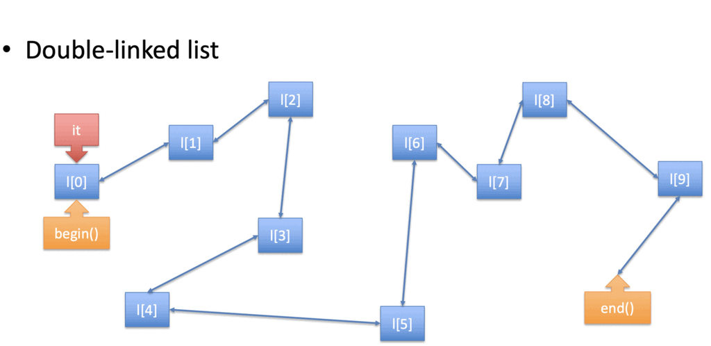

## Maps

`std::map` handles key-value pairs efficiently

https://www.online-ide.com/jbpHoZer2X

```
enum class Color { red, green, blue };

std::map<Color, std::string> ColorMap = {
      {Color::red,   “red”},
      {Color::green, “green”},
      {Color::blue,  ”blue”}
  };
std::cout << ColorMap[Color::green] << "\n";
```

## Maps

`std::map` handles key-value pairs efficiently

https://www.online-ide.com/Qekz72cqHF

```
enum class Color { red, green, blue };

std::map<std::string, Color> ColorMapReverse = {
        {"red", Color::red},
      {"green", Color::green},
      {"blue",  Color::blue}
  };

auto it = ColorMapReverse.find("green");

std::cout << it->first        // key
          << (int)it->second // value
          << "\n";
```

## Tuples

Container `std::tuples` stores **heterogeneous types**

```
#include <tuple>
auto t = std::make_tuple(3.8, ‘A’, “String”);
```

Access to individual elements

```
std::cout << std::get<0>(t) << std::endl; //Output: 3.8
std::cout << std::get<1>(t) << std::endl; //Output: A
std::cout << std::get<2>(t) << std::endl; //Output: String
```

Create tuple from parameter pack

```
auto t = std::tuple<Ts...>(args...);
```

## Tuples

Get the size of the tuple

```
std::cout << std::tuple_size<decltype(t)>::value;
```

However, it is impossible to iterate over the elements of a tuple using any of the run-time techniques seen before

- No operator[]
- No iterators
- No range-based or for-each loops

**Task:** Find a way to iterate over the elements of a tuple using compile-time techniques

## Tuples

https://www.online-ide.com/cygjF7U2vI

```
template<int N, typename Tuple> struct printer {
      static void print(Tuple t) {
          printer<N-1,Tuple>::print(t);
          std::cout << std::get<N>(t) << "\n";
}};
  // Specialization for first entry
  template<typename Tuple>
  struct printer<0,Tuple> {
      static void print(Tuple t) {
          std::cout << std::get<0>(t) << "\n";
}};
```

## Tuples

Usage

```
int main() {
    auto t = std::make_tuple(3.8, ‘A’, “String”);
    printer<std::tuple_size<decltype(t)>::value-1,
             decltype(t)>::print(t);
}
```